# CW 1

Thaheer

2026-10-12

```r
library(tidyverse)
library(scales)
library(patchwork)
library(ggforce)
library(GGally)
library(knitr)
```

# 1. Question and dataset context

What is the nightly price difference between entire homes and private rooms in the three London boroughs of Westminster, Hackney and Croydon?

**Source** This report uses the detailed London listings file published by Inside Airbnb, which collects publicly available Airbnb data and distributes it under a Creative Commons Attribution 4.0 licence.

**Structure** The dataset contains 91,954 listings, each row representing one individual Airbnb property, scraped between 18 and 23 September 2026.

**Variables used** This analysis uses each listing’s borough, room type, advertised price, guest capacity, review score and availability.

| Limitation | Explanation |
| --- | --- |
| Advertised, not actual price | The price column shows what the host asks for, not what a guest actually paid. |
| Self-selected hosts | Only people who chose to list on Airbnb appear here, so the data reflects Airbnb hosts, not London housing generally. |
| One snapshot in time | The data was collected over one week in September 2026, so it cannot show how prices change by season. |
| Approximate location | Airbnb shifts each listing’s coordinates slightly for host privacy, so only borough-level location can be trusted. |

Because of these limitations, the price comparisons in this report should be read as a description of what hosts in Westminster, Hackney and Croydon currently advertise, not as a measure of true market rents or of how much guests pay in practice.

# 2. Data preparation and workflow

```r
listings <- read_csv("data/listings.csv", show_col_types = FALSE)

dim(listings)
```

```
## [1] 91954    90
```

```r
#price column specifically:

listings |> select(price) |> head(10)
```

```
## # A tibble: 10 × 1
##    price
##    <chr>
##  1 $267.50
##  2 $127.00
##  3 $137.50
##  4 $228.00
##  5 <NA>
##  6 $290.00
##  7 $517.50
##  8 <NA>
##  9 <NA>
## 10 $59.00
```

```r
class(listings$price)
```

```
## [1] "character"
```

Filtering the data and fixing price:

```r
boroughs <- c("Westminster", "Hackney", "Croydon")
room_types <- c("Entire home/apt", "Private room")

scope <- listings |>
  filter(neighbourhood_cleansed %in% boroughs,
         room_type %in% room_types) |>
  mutate(
    price = parse_number(price),     # Converting price col text to number
    borough = factor(neighbourhood_cleansed, levels = boroughs)
  )

dim(scope)
```

```
## [1] 18141    91
```

```r
#Checking for missing price values:

scope |> summarise(missing_price = mean(is.na(price)))
```

```
## # A tibble: 1 × 1
##   missing_price
##           <dbl>
## 1         0.342
```

```r
#checking why price is missing, which is the real insight:

scope |>
  mutate(no_availability = availability_365 == 0) |>
  group_by(no_availability) |>
  summarise(missing_price = mean(is.na(price)), n = n())
```

```
## # A tibble: 2 × 3
##   no_availability missing_price     n
##   <lgl>                   <dbl> <int>
## 1 FALSE                  0.0657 12651
## 2 TRUE                   0.978   5490
```

```r
grp <- scope |>
  group_by(borough, room_type) |>
  summarise(Listings = n(),
            `With price` = sum(!is.na(price)),
            `Missing price` = mean(is.na(price)),
            .groups = "drop")

grp |>
  mutate(`Missing price` = percent(`Missing price`)) |>
  rename(Borough = borough, `Room type` = room_type) |>
  kable(format.args = list(big.mark = ","), align = "llrrr",
        caption = "Table 1: Listings in scope, and how many lack a price.")
```

Table 1: Listings in scope, and how many lack a price.

| Borough | Room type | Listings | With price | Missing price |
| --- | --- | --- | --- | --- |
| Westminster | Entire home/apt | 8,783 | 6,637 | 24.4% |
| Westminster | Private room | 1,951 | 1,262 | 35.3% |
| Hackney | Entire home/apt | 3,793 | 1,962 | 48.3% |
| Hackney | Private room | 1,937 | 858 | 55.7% |
| Croydon | Entire home/apt | 909 | 656 | 27.8% |
| Croydon | Private room | 768 | 567 | 26.2% |

# 3. Exploratory visual analysis

## 3.1 Composition

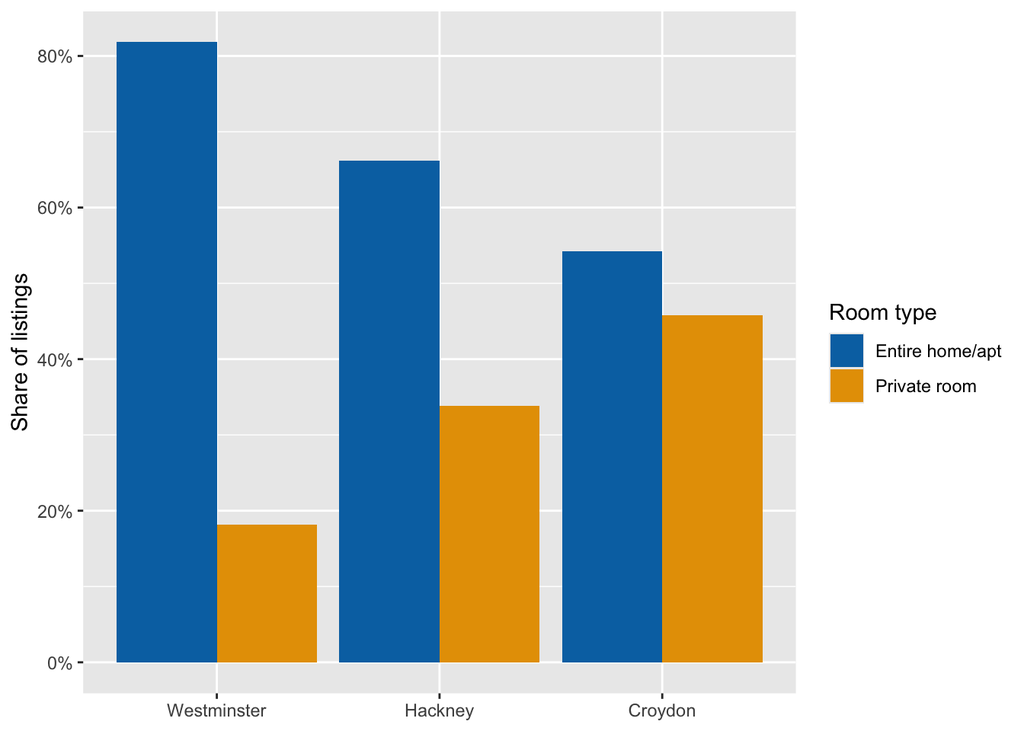

Figure 1: Share of entire homes vs private rooms, by borough.

```r
pal_room <- c("Entire home/apt" = "#0072B2", "Private room" = "#E69F00")


shares <- scope |>
  count(borough, room_type) |>
  group_by(borough) |>
  mutate(share = n / sum(n)) |>
  ungroup()

ggplot(shares, aes(borough, share, fill = room_type)) +
  geom_col(position = "dodge") +
  scale_fill_manual(values = pal_room) +
  scale_y_continuous(labels = percent) +
  labs(x = NULL, y = "Share of listings", fill = "Room type")
```

**Figure 1** shows the room-type mix varies sharply by borough: entire homes are 82% of Westminster listings, 66% of Hackney’s, but only 54% of Croydon’s. A bar chart suits this better than a pie chart, since position on a shared baseline is judged more accurately than angle (Cleveland and McGill, 1984). Because Westminster is entire-home-dominated, any borough comparison must account for room type separately.

## 3.2 Missing data

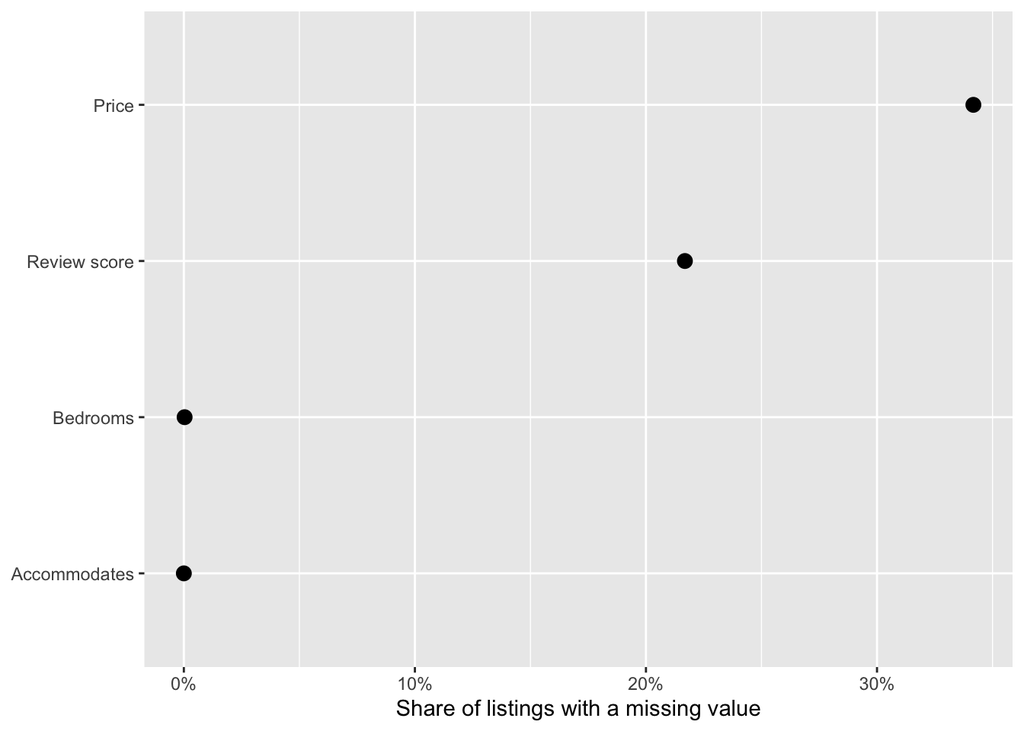

Figure 2: Share of missing values by variable.

```r
scope |>
  summarise(Price = mean(is.na(price)),
            `Review score` = mean(is.na(review_scores_rating)),
            Bedrooms = mean(is.na(bedrooms)),
            Accommodates = mean(is.na(accommodates))) |>
  pivot_longer(everything(), names_to = "variable", values_to = "share") |>
  mutate(variable = fct_reorder(variable, share)) |>
  ggplot(aes(share, variable)) +
  geom_point(size = 3) +
  scale_x_continuous(labels = percent) +
  labs(x = "Share of listings with a missing value", y = NULL)
```

**Figure 2** ranks variables by missingness. Price is least complete at 34%, then review score at 22%; bedrooms and capacity are essentially complete. A dot plot suits a ranking better than a bar chart, since only position, not area, matters here.

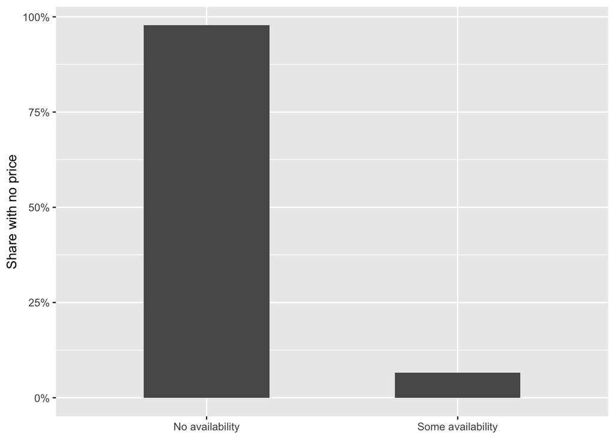

Figure 3: Share of listings with no price, by availability.

```r
scope |>
  mutate(no_availability = availability_365 == 0) |>
  group_by(no_availability) |>
  summarise(share = mean(is.na(price)), .groups = "drop") |>
  mutate(no_availability = if_else(no_availability, "No availability", "Some availability")) |>
  ggplot(aes(no_availability, share)) +
  geom_col(width = .5) +
  scale_y_continuous(labels = percent) +
  labs(x = NULL, y = "Share with no price")
```

**Figure 3** explains the price gaps: among listings with zero available days, 98% lack a price, versus 7% of available listings. Airbnb appears to stop publishing a price once a listing is inactive, rather than prices being missing at random. so this report’s comparisons describe bookable listings, not the full stock ever listed.

## 3.3 Distribution of price

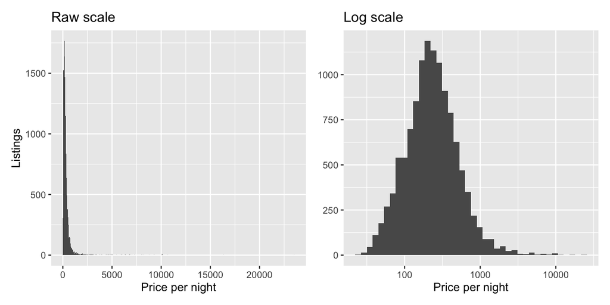

Figure 4: Nightly price on a raw scale (left) and log scale (right).

```r
dat <- scope |> filter(!is.na(price))

p_raw <- ggplot(dat, aes(price)) +
  geom_histogram(binwidth = 50, boundary = 0) +
  labs(title = "Raw scale", x = "Price per night", y = "Listings")

p_log <- ggplot(dat, aes(price)) +
  geom_histogram(bins = 40) +
  scale_x_log10() +
  labs(title = "Log scale", x = "Price per night", y = NULL)

p_raw + p_log
```

**Figure 4** compares raw and log scales. On the raw scale (left), almost all listings crowd near zero while the axis stretches past £20,000 for a few outliers, hiding the typical price. The log10 scale (right) reveals one roughly symmetric peak around £100–300. This is the standard fix for a long right tail: it changes only the axis spacing, not the values, making the typical price visible without deleting or capping outliers.

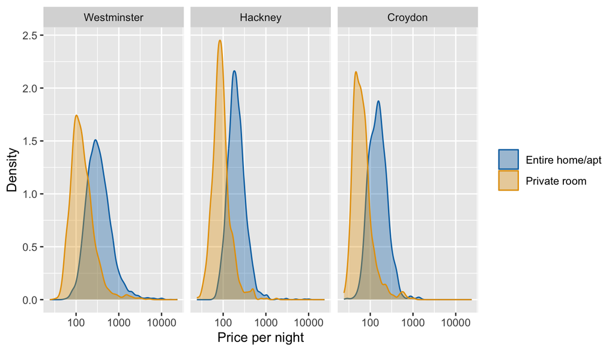

Figure 5: Density of price by room type, faceted by borough.

```r
ggplot(dat, aes(price, fill = room_type, colour = room_type)) +
  geom_density(alpha = .35) +
  facet_wrap(~ borough) +
  scale_x_log10() +
  scale_fill_manual(values = pal_room) +
  scale_colour_manual(values = pal_room) +
  labs(x = "Price per night", y = "Density", fill = NULL, colour = NULL)
```

**Figure 5** facets price density by borough and room type. In all three areas, private rooms (orange) sit left of entire homes (blue). cheaper everywhere, not just on average. The gap looks widest in Westminster, where the entire-home curve extends furthest right. a first hint that the gap is not uniform across boroughs, which Figure 6 checks more formally.

## 3.4 Comparing price across boroughs and room types

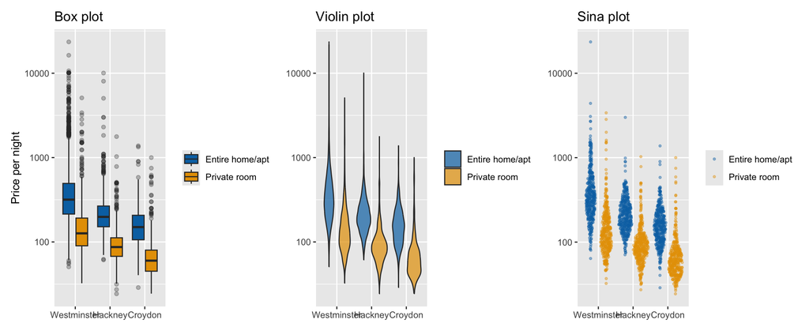

Figure 6: Price by borough and room type — box, violin and sina plots compared.

```r
p_box <- ggplot(dat, aes(borough, price, fill = room_type)) +
  geom_boxplot(outlier.alpha = .3) +
  scale_y_log10() +
  scale_fill_manual(values = pal_room) +
  labs(title = "Box plot", x = NULL, y = "Price per night", fill = NULL)

p_violin <- ggplot(dat, aes(borough, price, fill = room_type)) +
  geom_violin(alpha = .7) +
  scale_y_log10() +
  scale_fill_manual(values = pal_room) +
  labs(title = "Violin plot", x = NULL, y = NULL, fill = NULL)

set.seed(7413)

dat_sample <- dat |>
  group_by(borough, room_type) |>
  slice_sample(n = 400) |>
  ungroup()

p_sina <- ggplot(dat_sample, aes(borough, price, colour = room_type)) +
  geom_sina(alpha = .4, size = .8) +
  scale_y_log10() +
  scale_colour_manual(values = pal_room) +
  labs(title = "Sina plot", x = NULL, y = NULL, colour = NULL)

p_box + p_violin + p_sina
```

## 3.5 Price and capacity

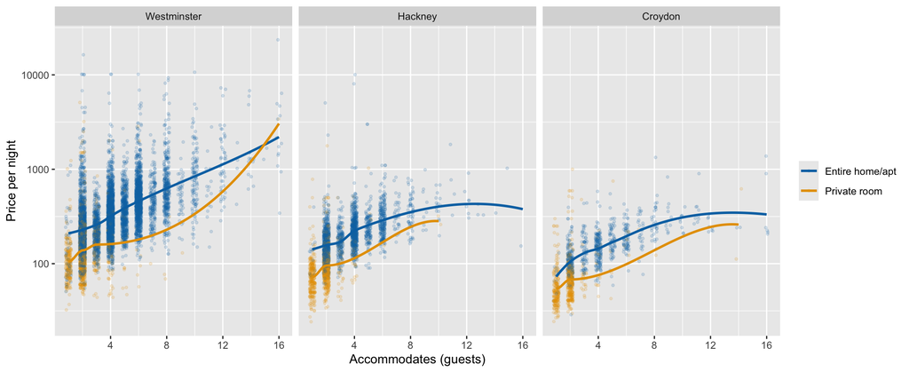

Figure 7: Price against guest capacity, with a loess smooth, by borough and room type.

```r
ggplot(dat, aes(accommodates, price, colour = room_type)) +
  geom_jitter(width = .2, alpha = .15, size = .8) +
  geom_smooth(method = "loess", se = FALSE, linewidth = 1) +
  scale_y_log10() +
  scale_colour_manual(values = pal_room) +
  facet_wrap(~ borough) +
  labs(x = "Accommodates (guests)", y = "Price per night", colour = NULL)
```

**Figure 7** shows price rising with capacity in all boroughs, but not linearly: in Hackney and Croydon both lines flatten above roughly 8–10 guests, a diminishing-returns pattern a straight-line fit would miss. The room-type gap stays fairly constant in Hackney and Croydon, but crosses near the top of Westminster’s scale, likely noise, since few Westminster private rooms sleep more than 12 guests, rather than a reliable reversal.

## 3.6 Price and review score

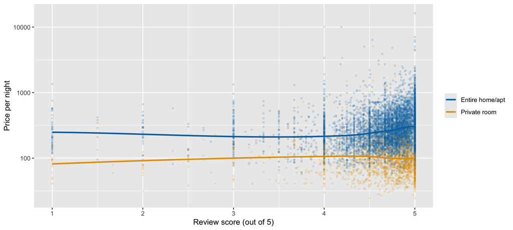

Figure 8: Price against review score, by room type.

```r
dat_reviewed <- dat |> filter(!is.na(review_scores_rating))

ggplot(dat_reviewed, aes(review_scores_rating, price, colour = room_type)) +
  geom_point(alpha = .15, size = .8) +
  geom_smooth(method = "loess", se = FALSE, linewidth = 1) +
  scale_y_log10() +
  scale_colour_manual(values = pal_room) +
  labs(x = "Review score (out of 5)", y = "Price per night", colour = NULL)
```

**Figure 8** shows a far weaker relationship than Figure 7: both trend lines stay close to flat between scores of 2 and 4, with only a mild rise for entire homes near a perfect score. The low-score end is unreliable, since Airbnb ratings skew heavily toward 4.5–5. Together, Figures 7 and 8 suggest capacity drives price far more than review score does.

## 3.7 Outliers and anomalies

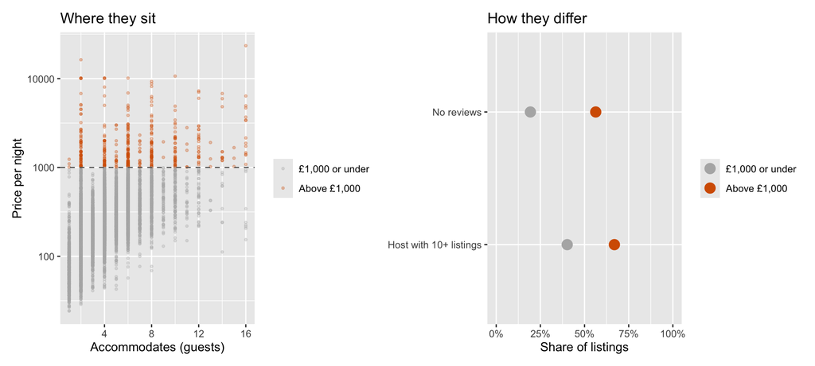

Figure 9: Listings above £1,000 per night — where they sit (left) and how they differ (right).

```r
dat2 <- dat |>
  mutate(
    flag = price > 1000,
    no_reviews = is.na(review_scores_rating),
    multi_host = calculated_host_listings_count >= 10
  )

p_out1 <- ggplot(dat2, aes(accommodates, price, colour = flag)) +
  geom_point(alpha = .3, size = .8) +
  geom_hline(yintercept = 1000, linetype = "dashed", colour = "grey40") +
  scale_y_log10() +
  scale_colour_manual(values = c("FALSE" = "grey70", "TRUE" = "#D55E00"),
                       labels = c("FALSE" = "£1,000 or under", "TRUE" = "Above £1,000")) +
  labs(x = "Accommodates (guests)", y = "Price per night", colour = NULL,
       title = "Where they sit")

comp <- dat2 |>
  group_by(flag) |>
  summarise(`No reviews` = mean(no_reviews),
            `Host with 10+ listings` = mean(multi_host, na.rm = TRUE)) |>
  pivot_longer(-flag, names_to = "trait", values_to = "share")

p_out2 <- ggplot(comp, aes(share, trait, colour = flag)) +
  geom_point(size = 4) +
  scale_x_continuous(labels = percent, limits = c(0, 1)) +
  scale_colour_manual(values = c("FALSE" = "grey70", "TRUE" = "#D55E00"),
                       labels = c("FALSE" = "£1,000 or under", "TRUE" = "Above £1,000")) +
  labs(x = "Share of listings", y = NULL, colour = NULL, title = "How they differ")

p_out1 + p_out2
```

# 4. Interpretation and design justification

This report asked: what is the nightly price difference between entire homes and private rooms in Westminster, Hackney and Croydon? The answer is consistent across every view in Section 3: entire homes cost roughly 2–2.5 times more in all three boroughs, with Westminster dearest and Croydon cheapest. The gap appears identically in the box, violin and sina plots (Figure 6), and holds after accounting for capacity (Figure 7), ruling out the simplest alternative, that it is really just a capacity difference in disguise.

# 5. Limitations and further analysis

This analysis has further limitations. It identifies associations and group differences but does not formally test significance or control for several variables at once; a regression including borough, room type and capacity would isolate each effect’s size. Missing prices were linked to availability (Figure 3) but not fully explained, host responsiveness or recent listing changes may also contribute. The high-price outliers (Figure 9) were linked to missing reviews and multi-listing hosts, but the data cannot confirm whether these prices are deliberate or simply unmaintained. Finally, this report covers only three of London’s 33 boroughs; the same pattern may not hold elsewhere, so extending the analysis city-wide is a natural next step.